# Lab #5

Jung Ho Suh

```r
acc <- read.csv("https://raw.githubusercontent.com/xdaiISU/ds202materials/master/hwlabs/fars2017/accident.csv", stringsAsFactors = FALSE)
per <- read.csv("https://raw.githubusercontent.com/xdaiISU/ds202materials/master/hwlabs/fars2017/person.csv", stringsAsFactors = FALSE)
```

*1. Create a data frame containing the persons who are fatally hurt in the accidents (see FARS manual and look up variable INJ_SEV)*

```r
library(dplyr)
library(tidyr)

fatal_hurt <- per %>%
  filter(INJ_SEV == 4)
```

*2. Create a data frame containing the most dangerous vehicle make in each state. The number of persons fatally hit in the vehicle make is used to assess the (non-)safety of a make. Make sure to handle the missing values appropriately. (look up variable MAKE)*

```r
library(dplyr)
library(tidyr)

make_by_fatal_hit <- fatal_hurt %>%
  group_by(MAKE,STATE) %>%
  mutate(
    total = n()
  ) %>%
  filter(!(is.na(MAKE))) %>%
  select(c(STATE,MAKE,total)) %>%
  arrange(STATE,desc(total)) %>%
  distinct() %>%
  ungroup() %>%
  group_by(STATE) %>%
  slice(1)
```

*3. Create a map, and label each state with the most dangerous vehicle. Discuss the definition of the most dangerous vehicle, and what you find from the map. (Hint: Read the description for the STATE and COUNTY columns in the FARS manual. The state & county codes are Geographic Locator Codes (GLCs) from the General Services Administration’s (GSA) publication. Use readxl::read_xlsx to read in the GLCs.)*

It seems like there are many Ford(12) and Chevrolet(20) involved in fatal accident. Followed by Honda(37) and Toyota(49). However, I would not accuse them for the fatality of the accident because this does not account the total number of vehicle sold. I would dive deeper into this matter and conclude if the make of the vehicle is actually “dangerous”.

```r
library(dplyr)
library(tidyr)
library(ggplot2)

geoloc <- readxl::read_xlsx("FRPP_GLC_-_United_StatesNov42021.xlsx")
geoloc <- geoloc %>%
  select(c(`State Name`, `State Code`)) %>%
  mutate(
    State_Name = `State Name`,
    State_Code = as.integer(`State Code`)
  ) %>%
  select(c(State_Name,State_Code)) %>%
  distinct()

str(geoloc)
```

```
## tibble [51 x 2] (S3: tbl_df/tbl/data.frame)
##  $ State_Name: chr [1:51] "ALABAMA" "ALASKA" "ARIZONA" "ARKANSAS" ...
##  $ State_Code: int [1:51] 1 2 4 5 6 8 9 10 11 12 ...
```

```r
joined_geoloc <- make_by_fatal_hit %>%
  left_join(geoloc, by = c("STATE" = "State_Code")) %>%
  mutate(
    state_name = tolower(State_Name)
  )

library(tidyverse)
```

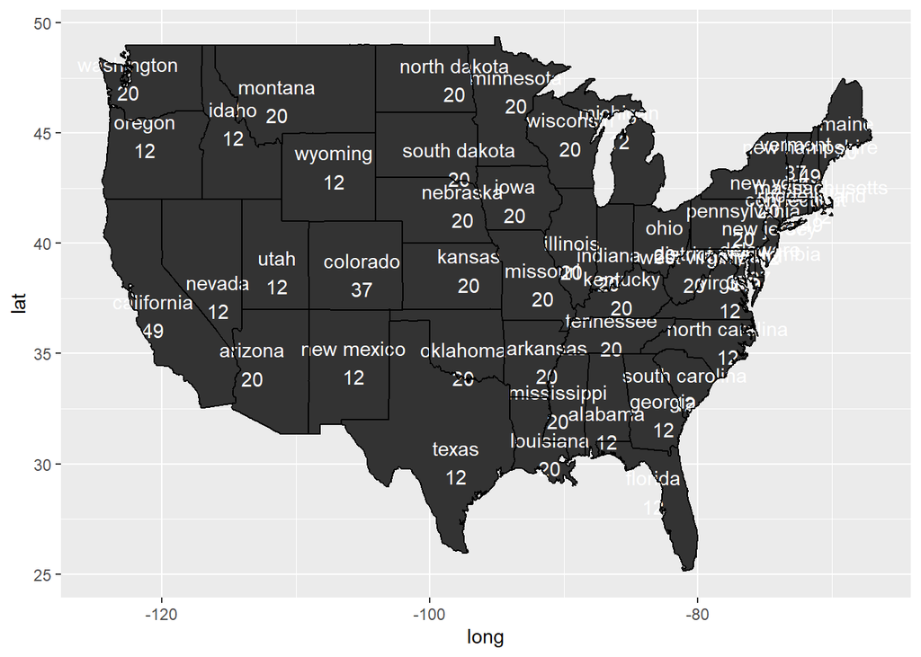

```r
states <- map_data('state')

stateName <- states %>% group_by(region) %>% summarize(long=mean(long), lat=mean(lat)) %>% left_join(joined_geoloc, by =c("region" = "state_name")) %>% mutate(
  statenameandmake = paste(region, MAKE, sep = "\n")
)

states %>% ggplot(aes(x = long, y = lat)) +
  geom_polygon(aes(group = group)) +
  geom_text(aes(label=statenameandmake), color='white', data=stateName) +
  geom_path(aes(group=group))
```

```r
  coord_map()
```

[output not shown]

*4.Join the accident and person table (work out which variable(s) to use)*

ST_CASE should be used to merge the Person data file with the Accident data file for a set of all motorists and non-motorists.

```r
library(dplyr)
library(tidyr)
library(ggplot2)

mergedaccper <- per %>%
  left_join(acc, by = c("ST_CASE" = "ST_CASE"))
```

*5.Tally the number of accidents by day of the week (DAY_WEEK), hour of the day (HOUR) and gender (SEX). Visualize the results and explain what you find.*

Weekends tend to be more accidents than the weekdays. Hour after 12PM is more dangerous than others, peaked in 6PM. Male tend to be in more accident than female.

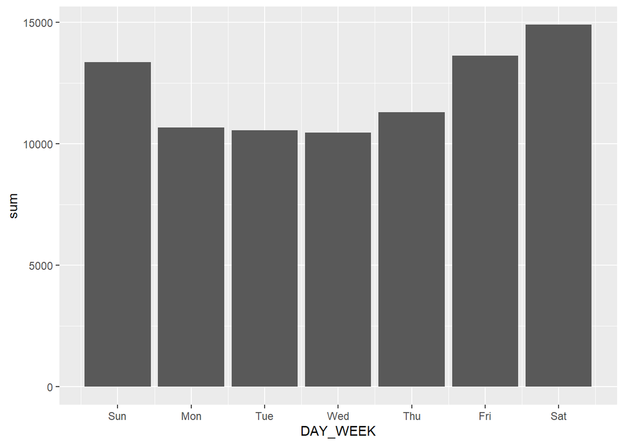

```r
library(dplyr)
library(tidyr)
library(ggplot2)

bydayweek <- mergedaccper %>%
  group_by(DAY_WEEK) %>%
  mutate(
    sum = n()
  ) %>%
  select(c(DAY_WEEK, sum)) %>%
  distinct() %>%
  arrange(DAY_WEEK)

plt1 <- bydayweek %>%
  ggplot(aes(x=DAY_WEEK, y = sum)) + geom_bar(stat = "identity") + scale_x_continuous(breaks =seq(1,7,by=1), labels = c("Sun", "Mon", "Tue","Wed","Thu","Fri","Sat"))
show(plt1)
```

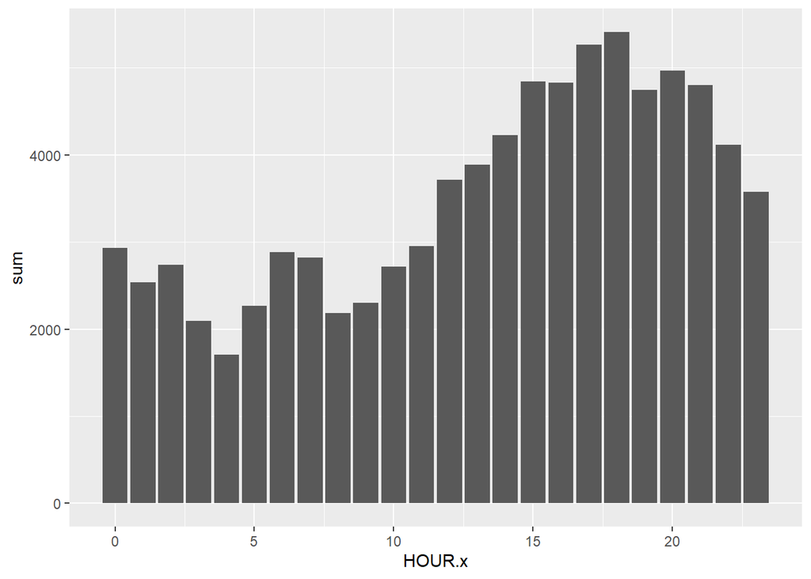

```r
byhour <- mergedaccper %>%
  group_by(HOUR.x) %>%
  mutate(
    sum = n()
  ) %>%
  select(c(HOUR.x, sum)) %>%
  distinct() %>%
  arrange(HOUR.x) %>%
  filter(!HOUR.x ==99)

plt2 <- byhour %>%
  ggplot(aes(x=HOUR.x, y = sum)) + geom_bar(stat = "identity")
show(plt2)
```

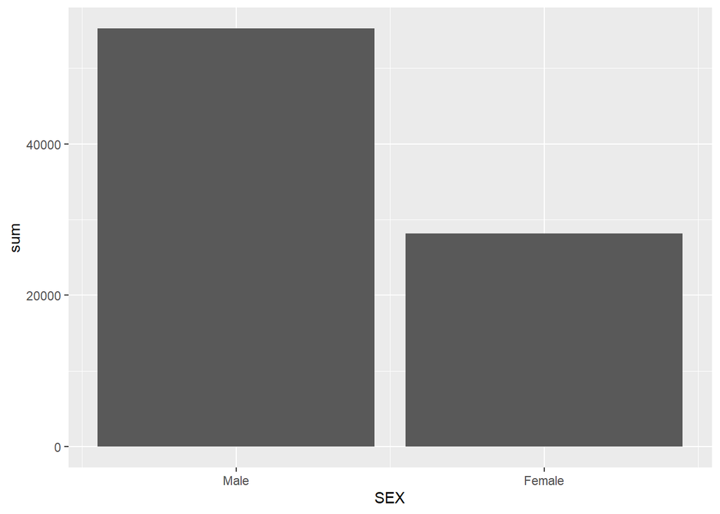

```r
bysex <- mergedaccper %>%
  group_by(SEX) %>%
  mutate(
    sum = n()
  ) %>%
  select(c(SEX, sum)) %>%
  distinct() %>%
  arrange(SEX) %>%
  filter(SEX == 1 | SEX ==2)

plt3 <- bysex %>%
  ggplot(aes(x=SEX, y = sum)) + geom_bar(stat = "identity") + scale_x_continuous(breaks =seq(1,2,by=1), labels = c("Male", "Female"))
show(plt3)
```

*6.Now plot a choropleth map of the number of deaths on a county level. Also explain what you find.*

It seems like the east side of the nation suffers more death in accidents. I believe that it is largely dependent to the population and the population density. For west side, it is mostly Seattle and California areas that suffers the fatal accidents.

```r
library(dplyr)
library(tidyr)
library(ggplot2)

geoloc <- readxl::read_xlsx("FRPP_GLC_-_United_StatesNov42021.xlsx")
countygeoloc <- geoloc %>%
  select(c(`State Name`, `State Code`, `County Name`, `County Code`)) %>%
  mutate(
    State_Name = `State Name`,
    State_Code = as.integer(`State Code`),
    County_Name = `County Name`,
    County_Code = as.integer(`County Code`)
  ) %>%
  select(c(State_Name,State_Code,County_Name,County_Code)) %>%
  distinct()

str(countygeoloc)
```

```
## tibble [3,149 x 4] (S3: tbl_df/tbl/data.frame)
##  $ State_Name : chr [1:3149] "ALABAMA" "ALABAMA" "ALABAMA" "ALABAMA" ...
##  $ State_Code : int [1:3149] 1 1 1 1 1 1 1 1 1 1 ...
##  $ County_Name: chr [1:3149] "HENRY" "MARSHALL" "TALLAPOOSA" "PICKENS" ...
##  $ County_Code: int [1:3149] 67 95 123 107 39 77 15 109 83 73 ...
```

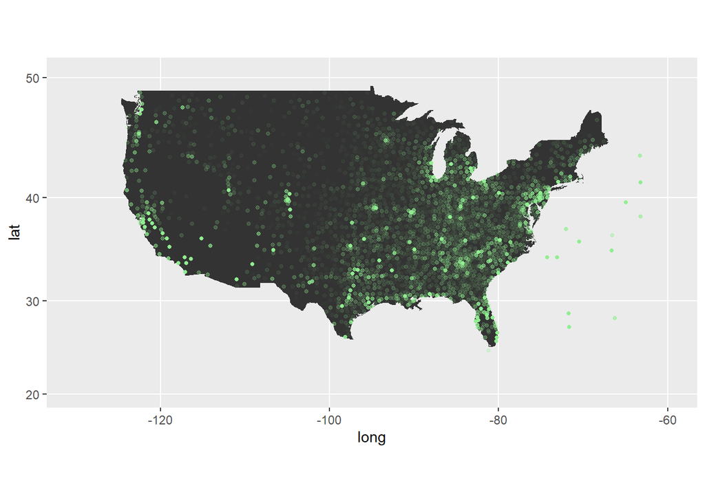

```r
byfatalcounty <- mergedaccper %>%
  filter(INJ_SEV == 4) %>%
  group_by(STATE.x,COUNTY.x) %>%
  mutate(
    sum = n()
  ) %>%
  select(c(STATE.x, COUNTY.x, sum, LONGITUD,LATITUDE)) %>%
  distinct() %>%
  arrange(STATE.x,COUNTY.x)

joined_countygeoloc <- byfatalcounty %>%
  left_join(countygeoloc, by = c("STATE.x" = "State_Code", "COUNTY.x" = "County_Code")) %>%
  mutate(
    state_name = tolower(State_Name),
    county_name = tolower(County_Name),
    longitude = mean(LONGITUD),
    latitude = mean(LATITUDE)
  ) %>%
  ungroup() %>%
  mutate(
    maxpercentage = sum/max(sum)
  ) %>%
  select(c(state_name,county_name, longitude,latitude,maxpercentage,sum)) %>%
  distinct()

library(tidyverse)
states <- map_data('state')

ggplot(states, aes(x=long, y=lat)) +
  geom_polygon(aes(group=group)) +
  geom_point(aes(x=longitude, y=latitude), data=joined_countygeoloc,
             color='lightgreen',
             alpha=joined_countygeoloc$maxpercentage*10, size=1) +
  xlim(-130, -60) + ylim(20, 50) +
  coord_map()
```